# Exercise on Microarray Data Analysis

Ferriol Calvet

June 17, 2019

```r
## ----loadPackages, message=FALSE, warning=FALSE, eval=FALSE-----------
require("colorspace")
require("gplots")
require("ggplot2")
require("ggrepel")

require("BiocManager")
require("ReactomePA")
require("org.Mm.eg.db")
require("annotate")
require("mogene10sttranscriptcluster.db")
require("pvca")
require("genefilter")
require("limma")
require("arrayQualityMetrics")
require("oligo")
```

# Read files

We need two different informations as input, on the one hand the targets file, and on the other hand the expression data. We will read the targets file as a normal tsv file, and for the data we will use *read.celfiles* function. We will also store the targets dataframe in *AnnotatedDataFrame* format. Finally, we make sure that the names of the rows and the columns are the appropiate ones.

```r
## ----ReadTargets---------------------------------------------------------
targets <- read.csv2("./data/targets.csv", header = TRUE, sep = "\t")
print(targets)
```

```
##    SampleName Muscle Treatment Replicate Color   ShortName     Group
## 1  GSM1720833   quad   control         1     1 quad_ctrl_1 quad_ctrl
## 2  GSM1720834   quad   control         2     1 quad_ctrl_2 quad_ctrl
## 3  GSM1720835   quad   control         3     1 quad_ctrl_3 quad_ctrl
## 4  GSM1720836   quad   control         4     1 quad_ctrl_4 quad_ctrl
## 5  GSM1720837   quad   control         5     1 quad_ctrl_5 quad_ctrl
## 6  GSM1720838   quad   control         6     1 quad_ctrl_6 quad_ctrl
## 7  GSM1720839   quad       cKO         1     2   quad_KO_1   quad_KO
## 8  GSM1720840   quad       cKO         2     2   quad_KO_2   quad_KO
## 9  GSM1720841   quad       cKO         3     2   quad_KO_3   quad_KO
## 10 GSM1720842   quad       cKO         4     2   quad_KO_4   quad_KO
## 11 GSM1720843   quad       cKO         5     2   quad_KO_5   quad_KO
## 12 GSM1720844   quad       cKO         6     2   quad_KO_6   quad_KO
## 13 GSM1720845 soleus   control         1     3  sol_ctrl_1  sol_ctrl
## 14 GSM1720846 soleus   control         2     3  sol_ctrl_2  sol_ctrl
## 15 GSM1720847 soleus   control         3     3  sol_ctrl_3  sol_ctrl
## 16 GSM1720848 soleus   control         4     3  sol_ctrl_4  sol_ctrl
## 17 GSM1720849 soleus   control         5     3  sol_ctrl_5  sol_ctrl
## 18 GSM1720850 soleus   control         6     3  sol_ctrl_6  sol_ctrl
## 19 GSM1720851 soleus       cKO         1     4    sol_KO_1    sol_KO
## 20 GSM1720852 soleus       cKO         2     4    sol_KO_2    sol_KO
## 21 GSM1720853 soleus       cKO         3     4    sol_KO_3    sol_KO
## 22 GSM1720854 soleus       cKO         4     4    sol_KO_4    sol_KO
## 23 GSM1720855 soleus       cKO         5     4    sol_KO_5    sol_KO
## 24 GSM1720856 soleus       cKO         6     4    sol_KO_6    sol_KO
```

```r
## ----ReadCELfiles, message=FALSE, results='hide', warning=FALSE----------
require(oligo)
celFiles <- list.celfiles("./data", full.names = TRUE)
my.targets <-read.AnnotatedDataFrame(file.path("./data","targets.csv"),
                                     header = TRUE, row.names = 1,
                                     sep="\t")
rawData <- read.celfiles(celFiles, phenoData = my.targets)
```

```
## Platform design info loaded.
```

```
## Reading in : ./data/GSM1720833_ControlQuad1.CEL
## Reading in : ./data/GSM1720834_ControlQuad2.CEL
## Reading in : ./data/GSM1720835_ControlQuad3.CEL
## Reading in : ./data/GSM1720836_ControlQuad4.CEL
## Reading in : ./data/GSM1720837_ControlQuad5.CEL
## Reading in : ./data/GSM1720838_ControlQuad6.CEL
## Reading in : ./data/GSM1720839_cKOQuad1.CEL
## Reading in : ./data/GSM1720840_cKOQuad2.CEL
## Reading in : ./data/GSM1720841_cKOQuad3.CEL
## Reading in : ./data/GSM1720842_cKOQuad4.CEL
## Reading in : ./data/GSM1720843_cKOQuad5.CEL
## Reading in : ./data/GSM1720844_cKOQuad6.CEL
## Reading in : ./data/GSM1720845_ControlSoleus1.CEL
## Reading in : ./data/GSM1720846_ControlSoleus2.CEL
## Reading in : ./data/GSM1720847_ControlSoleus3.CEL
## Reading in : ./data/GSM1720848_ControlSoleus4.CEL
## Reading in : ./data/GSM1720849_ControlSoleus5.CEL
## Reading in : ./data/GSM1720850_ControlSoleus6.CEL
## Reading in : ./data/GSM1720851_cKOSoleus1.CEL
## Reading in : ./data/GSM1720852_cKOSoleus2.CEL
## Reading in : ./data/GSM1720853_cKOSoleus3.CEL
## Reading in : ./data/GSM1720854_cKOSoleus4.CEL
## Reading in : ./data/GSM1720855_cKOSoleus5.CEL
## Reading in : ./data/GSM1720856_cKOSoleus6.CEL
```

```r
# dim(rawData@assayData$exprs)

## ----ChangeName----------------------------------------------------------
colnames(rawData) <-rownames(pData(rawData)) <- my.targets@data$ShortName
```

# Raw data evaluation

To perform the raw data evaluation we will use two different plots. First we will plot the Principal Component Analysis of our data, that allows us to see how the different samples are clustering or how are they distributed in relation to one another, and then we will use the boxplot to see how are the expression values of each sample distributed.

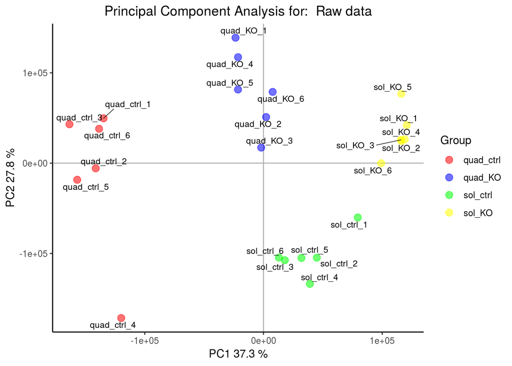

```r
require(ggplot2)
require(ggrepel)
plotPCA3 <- function (datos, labels, factor, title, scale,colores, size = 1.5, glineas = 0.25) {
  data <- prcomp(t(datos),scale=scale)
  # plot adjustments
  dataDf <- data.frame(data$x)
  Group <- factor
  loads <- round(data$sdev^2/sum(data$sdev^2)*100,1)
  # main plot
  p1 <- ggplot(dataDf,aes(x=PC1, y=PC2)) +
    theme_classic() +
    geom_hline(yintercept = 0, color = "gray70") +
    geom_vline(xintercept = 0, color = "gray70") +
    geom_point(aes(color = Group), alpha = 0.55, size = 3) +
    coord_cartesian(xlim = c(min(data$x[,1])-5,max(data$x[,1])+5)) +
    scale_fill_discrete(name = "Group")
  # avoiding labels superposition
  p1 + geom_text_repel(aes(y = PC2 + 0.25, label = labels),segment.size = 0.25, size = size) +
    labs(x = c(paste("PC1",loads[1],"%")),y=c(paste("PC2",loads[2],"%"))) +
    ggtitle(paste("Principal Component Analysis for: ",title,sep=" "))+
    theme(plot.title = element_text(hjust = 0.5)) +
    scale_color_manual(values=colores)
  }

## ----PCARaw, message=FALSE, fig.cap="Visualization of the two first Principal Components for raw data"----
plotPCA3(exprs(rawData), labels = targets$ShortName, factor = targets$Group,
         title="Raw data", scale = FALSE, size = 3,
         colores = c("red", "blue", "green", "yellow"))
```

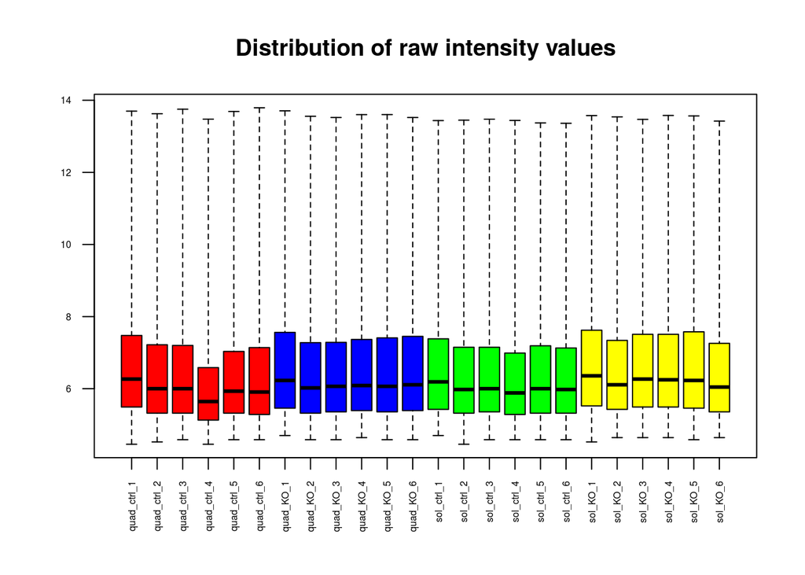

```r
## ----BoxplotRaw, message=FALSE, fig.cap="Boxplot for arrays intensities (Raw Data)"----
boxplot(rawData, cex.axis=0.5, las=2,  which="all",
         col = c(rep("red", 6), rep("blue", 6), rep("green", 6), rep("yellow", 6)),
         main="Distribution of raw intensity values")
```

```r
# ----QCRaw, message=FALSE, warning=FALSE, eval=FALSE---------------------
# require(arrayQualityMetrics)
# arrayQualityMetrics(rawData, outdir = file.path("./results", "QCDir.Raw"), force=TRUE)
# head(dim(exprs(rawData)))
```

# Normalization

As we see that there are some irregularities in the boxplot and that in the PCA some groups are not very compact, we will normalize the data using the *rma* function of the package *oligo*. From now on we will work with this normalized data.

```r
## ----Normalization---------------------------------------------
eset_rma <- rma(rawData)
```

```
## Background correcting
## Normalizing
## Calculating Expression
```

# Quality check of normalized data

After normalizing the data we perform the same quality check as before, however in this case we will use the function *arrayQualityMetrics* that outputs the results of this quality check automatically in a folder that can be found in the results directory.

```r
## ----QCNorm, message=FALSE, warning=FALSE, eval=FALSE--------------------
arrayQualityMetrics(eset_rma, outdir = file.path("./results", "QCDir.Norm"), force=TRUE)
```

```
## The report will be written into directory './results/QCDir.Norm'.
```

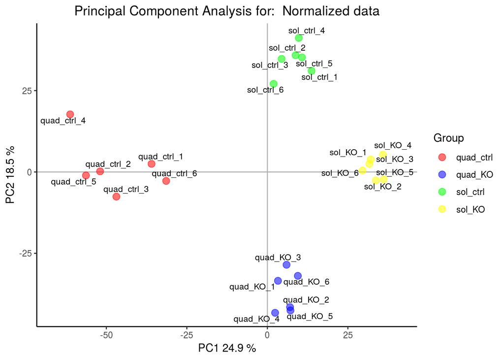

```r
## ----PCANorm, message=FALSE, fig.cap="Visualization of first two principal components for normalized data"----
plotPCA3(exprs(eset_rma), labels = targets$ShortName, factor = targets$Group,
         title="Normalized data", scale = FALSE, size = 3,
         colores = c("red", "blue", "green", "yellow"))
```

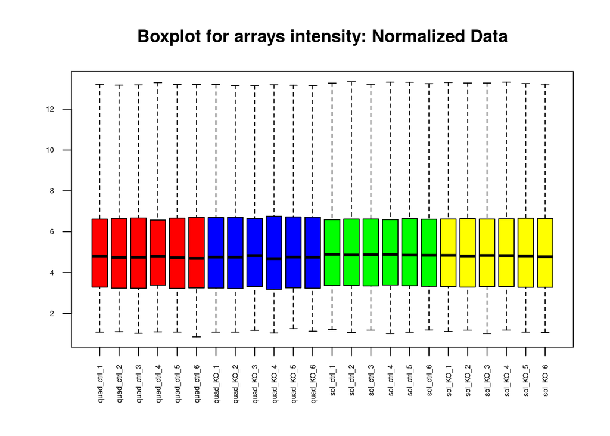

```r
## ----BoxplotNorm, message=FALSE, fig.cap="Distribution of  intensities for normalized data"----
boxplot(eset_rma, cex.axis=0.5, las=2,
         col = c(rep("red", 6), rep("blue", 6), rep("green", 6), rep("yellow", 6)),
         main="Boxplot for arrays intensity: Normalized Data")
```

```r
pData(eset_rma) <- targets
```

# Variation Plot

Now once we have made sure that the data is properly normalized, we look at the variance for each of the genes in the array. This way we will see the proportion of genes that are highly variable, if any.

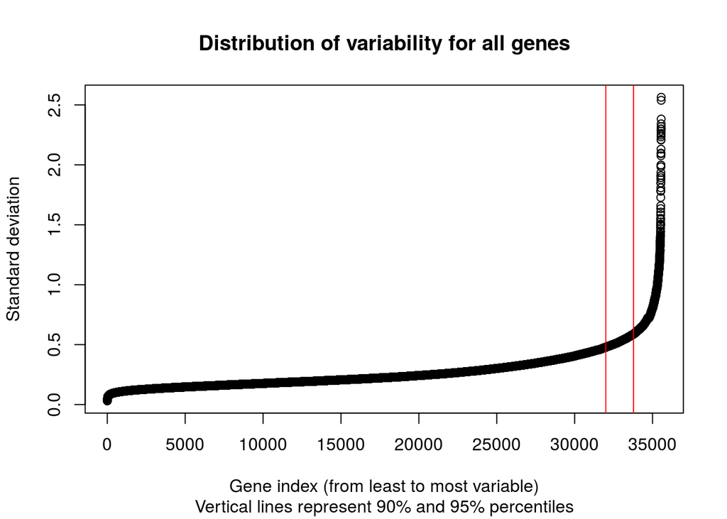

```r
## ----SDplot, fig.cap="Values of standard deviations allong all samples for all genes ordered from smallest to biggest"----
sds <- apply (exprs(eset_rma), 1, sd)
sdsO<- sort(sds)
plot(1:length(sdsO), sdsO, main="Distribution of variability for all genes",
     sub="Vertical lines represent 90% and 95% percentiles",
     xlab="Gene index (from least to most variable)", ylab="Standard deviation")
abline(v=length(sds)*c(0.9,0.95), col="red")
```

In this plot we can see that for almost 95 % of the genes, the standard deviation is below 0.5. This means that for these genes there is not enough variance to detect differential expression, and they should be removed from the analysis.

# Filter genes using variance cutoff

After concluding that some genes need to be discarded from the pool of candidate differentially expressed genes, we filter those genes whose variance is not in the top 25% when using the Interquartile Range as function.  
After the filtering is applied we obtain an expression set without all these genes that have been filtered out, and this is the data that will be used to continue the analysis.

```r
## ----Filtering1, results='hide', message=FALSE---------------------------
require(genefilter)
require(mogene10sttranscriptcluster.db)
annotation(eset_rma) <- "mogene10sttranscriptcluster.db"

filtered <- nsFilter(eset_rma,
                     require.entrez = TRUE, remove.dupEntrez = TRUE,
                     var.filter=TRUE, var.func=IQR, var.cutoff=0.75,
                     filterByQuantile=TRUE, feature.exclude = "^AFFX")

## ----FilterResults1, results='hide', echo=FALSE--------------------------
names(filtered)
```

```
## [1] "eset"       "filter.log"
```

```r
class(filtered$eset)
```

```
## [1] "ExpressionSet"
## attr(,"package")
## [1] "Biobase"
```

```r
## ----FilterResults2------------------------------------------------------
print(filtered$filter.log)
```

```
## $numDupsRemoved
## [1] 1781
##
## $numLowVar
## [1] 15230
##
## $numRemoved.ENTREZID
## [1] 13468
```

```r
eset_filtered <-filtered$eset

## ----SaveData1, results='hide', message=FALSE----------------------------
write.csv(exprs(eset_rma), file="./results/normalized.Data.csv")
write.csv(exprs(eset_filtered), file="./results/normalized.Filtered.Data.csv")
save(eset_rma, eset_filtered, file="./results/normalized.Data.Rda")

## ----LoadSavedData-------------------------------------------------------
if (!exists("eset_filtered")) load (file="./results/normalized.Data.Rda")
```

# Build Design and Contrast matrices

After having the data prepared, we now build the design and contrast matrices. The first one helps us to discriminate the 4 different groups in the experiment, and the second one allows us to define the comparisons that are rellevant for the analysis.  
In our case the rellevant comparisons are KO vs control in quadriceps and in soleus, and also soleus control vs quadriceps control.

```r
## ----DesignMatrix, message=FALSE-----------------------------------------
require(limma)
designMat<- model.matrix(~0+Group, pData(eset_filtered))
colnames(designMat) <- c("quad_ctrl","quad_KO","sol_ctrl","sol_KO")
print(designMat)
```

```
##    quad_ctrl quad_KO sol_ctrl sol_KO
## 1          1       0        0      0
## 2          1       0        0      0
## 3          1       0        0      0
## 4          1       0        0      0
## 5          1       0        0      0
## 6          1       0        0      0
## 7          0       1        0      0
## 8          0       1        0      0
## 9          0       1        0      0
## 10         0       1        0      0
## 11         0       1        0      0
## 12         0       1        0      0
## 13         0       0        1      0
## 14         0       0        1      0
## 15         0       0        1      0
## 16         0       0        1      0
## 17         0       0        1      0
## 18         0       0        1      0
## 19         0       0        0      1
## 20         0       0        0      1
## 21         0       0        0      1
## 22         0       0        0      1
## 23         0       0        0      1
## 24         0       0        0      1
## attr(,"assign")
## [1] 1 1 1 1
## attr(,"contrasts")
## attr(,"contrasts")$Group
## [1] "contr.treatment"
```

```r
## ----. setContrasts------------------------------------------------------
cont.matrix <- makeContrasts (
  quadctrlvsquadKO = quad_KO-quad_ctrl,
  solctrlvssolKO = sol_KO-sol_ctrl,
  quadctrlvssolCtrl = sol_ctrl-quad_ctrl,
  levels=designMat)
print(cont.matrix)
```

```
##            Contrasts
## Levels      quadctrlvsquadKO solctrlvssolKO quadctrlvssolCtrl
##   quad_ctrl               -1              0                -1
##   quad_KO                  1              0                 0
##   sol_ctrl                 0             -1                 1
##   sol_KO                   0              1                 0
```

# Fit a linear model and select significant hits

With the design and the contrast matrices defined we can go on with the analysis, and fit the linear model. By fitting this linear model, we estimate the parameters that define the relationship between the values of expression and the different groups defined in the design matrix.  
Once we have completed this step, we build the comparisons and we store in three different tables the results fro the three different comparison we defined in the contrast matrix.

```r
## ---- linearmodelfit-----------------------------------------------------
require(limma)
fit<-lmFit(eset_filtered, designMat)
fit.main<-contrasts.fit(fit, cont.matrix)
fit.main<-eBayes(fit.main)
class(fit.main)
```

```
## [1] "MArrayLM"
## attr(,"package")
## [1] "limma"
```

```r
## ---- topTabs1-----------------------------------------------------------
topTab_quadctrlvsquadKO <- topTable (fit.main, number=nrow(fit.main), coef="quadctrlvsquadKO", adjust="fdr")
head(topTab_quadctrlvsquadKO)
```

```
##             logFC  AveExpr        t      P.Value    adj.P.Val        B
## 10441003 2.869493 7.099847 25.69063 1.505334e-19 7.642583e-16 34.49783
## 10473312 3.553068 7.632540 22.33261 4.398375e-18 1.116527e-14 31.30299
## 10376765 4.199728 5.727741 20.59160 3.049267e-17 5.160376e-14 29.43923
## 10471247 1.996350 6.688491 20.18700 4.883341e-17 6.198181e-14 28.98299
## 10427075 2.853920 5.886382 19.90150 6.842890e-17 6.948271e-14 28.65547
## 10447190 2.312243 7.136006 19.18380 1.629107e-16 1.167888e-13 27.81099
```

```r
## ---- topTabs2-----------------------------------------------------------
topTab_solctrlvssolKO <- topTable (fit.main, number=nrow(fit.main), coef="solctrlvssolKO", adjust="fdr")
head(topTab_solctrlvssolKO)
```

```
##             logFC  AveExpr        t      P.Value    adj.P.Val        B
## 10473312 3.438468 7.632540 21.61229 9.633392e-18 4.890873e-14 30.27584
## 10349980 4.371007 9.511187 18.53593 3.654095e-16 9.275921e-13 26.86916
## 10456400 2.331273 8.020240 17.11832 2.339097e-15 3.958533e-12 25.09676
## 10387536 2.100779 6.239272 16.35857 6.680995e-15 8.033112e-12 24.08642
## 10474467 3.611892 4.357813 16.23890 7.911279e-15 8.033112e-12 23.92319
## 10504668 3.055824 6.100726 15.34751 2.881296e-14 2.438057e-11 22.67041
```

```r
## ---- topTabs3-----------------------------------------------------------
topTab_quadctrlvssolCtrl  <- topTable (fit.main, number=nrow(fit.main) , coef="quadctrlvssolCtrl", adjust="fdr")
head(topTab_quadctrlvssolCtrl)
```

```
##              logFC   AveExpr         t      P.Value    adj.P.Val        B
## 10366446 -3.893878  6.046368 -19.45270 1.173214e-16 4.614448e-13 28.08183
## 10589602  2.541868 10.372260  19.09477 1.817785e-16 4.614448e-13 27.65933
## 10501098 -1.853773  7.040789 -17.90218 8.249612e-16 1.123984e-12 26.19262
## 10574632 -1.682219  7.859510 -17.78667 9.595162e-16 1.123984e-12 26.04552
## 10556381 -1.968357  7.949260 -17.67799 1.106937e-15 1.123984e-12 25.90627
## 10539017 -1.754263  6.995042 -17.21417 2.054772e-15 1.574915e-12 25.30262
```

# Annotate the top hits of each comparison

This three tables we have just defined with the results of the linear model, can be annotated using the proper reference for our array, remember that, in this case, the annotation package that allows us to annotate our data is *“mogene10sttranscriptcluster.db”*.

```r
## ----GeneAnnotation, message=FALSE, warning=FALSE------------------------
annotatedTopTable <- function(topTab, anotPackage)
{
  topTab <- cbind(PROBEID=rownames(topTab), topTab)
  myProbes <- rownames(topTab)
  thePackage <- eval(parse(text = anotPackage))
  geneAnots <- select(thePackage, myProbes, c("SYMBOL", "ENTREZID", "GENENAME"))
  annotatedTopTab<- merge(x=geneAnots, y=topTab, by.x="PROBEID", by.y="PROBEID")
return(annotatedTopTab)
}

## ----annotateTopTables---------------------------------------------------
topAnnotated_quadctrlvsquadKO <- annotatedTopTable(topTab_quadctrlvsquadKO,
                                                   anotPackage="mogene10sttranscriptcluster.db")
topAnnotated_solctrlvssolKO <- annotatedTopTable(topTab_solctrlvssolKO,
                                                 anotPackage="mogene10sttranscriptcluster.db")
topAnnotated_quadctrlvssolCtrl <- annotatedTopTable(topTab_quadctrlvssolCtrl,
                                                    anotPackage="mogene10sttranscriptcluster.db")
write.csv(topAnnotated_quadctrlvsquadKO, file="./results/topAnnotated_quadctrlvsquadKO.csv")
write.csv(topAnnotated_solctrlvssolKO, file="./results/topAnnotated_solctrlvssolKO.csv")
write.csv(topAnnotated_quadctrlvssolCtrl, file="./results/topAnnotated_quadctrlvssolCtrl.csv")
```